# Algoritmos de clasificación: SVM, Árboles de decisión simples y múltiples (random forest)

ENRIQUE ROCHO SIMON

Enero 2023

# 1 Introducción

## 1.1 Descripción de la PEC a realizar

La prueba está estructurada en 6 ejercicios teórico-prácticos que piden que se desarrolle la fase de preparación y estimación de un modelo supervisado utilizando un juego de datos.

Deben responderse al menos 4 de los 6 ejercicios para poder superar la PEC. Para optar a la máxima nota tienen que responderse todos los ejercicios de forma correcta.

## 1.2 Criterios de evaluación

**Ejercicios teóricos**  
Todos los ejercicios deben ser presentados de forma razonada y clara. No se aceptará ninguna respuesta que no esté claramente justificada.

**Ejercicios prácticos**  
Para todas las PEC es necesario documentar en cada ejercicio práctico qué se ha hecho y cómo se ha hecho.

| Pregunta | Criterio de valoración | Peso |
| --- | --- | --- |
| 1 | Se realiza el primer gráfico | 5% |
| 1 | El primer gráfico tiene los colores y formas adecuados | 5% |
| 1 | Se realiza el segundo gráfico | 5% |
| 1 | El segundo gráfico tiene los colores y formas adecuados | 5% |
| 2 | Se entrena el modelo de la familia RandomForest que no es RF | 5% |
| 2 | Se muestra la matriz de confusión | 5% |
| 2 | Se define la Sensibilidad | 5% |
| 2 | Se analizano los valores de Sensibilidad de las 3 clases | 5% |
| 3 | Se entrena el modelo solicitado | 10% |
| 3 | Se compara el resultado con el otro modelo | 5% |
| 4 | Se entrena el modelo | 5% |
| 4 | Se evalua el modelo | 5% |
| 4 | Se representa gráficamente | 5% |
| 4 | Se describen todas las reglas | 5% |
| 4 | Se razona la respuesta | 5% |
| 5 | Se elige una variante y se describe | 5% |
| 5 | Se entrena el modelo variante | 5% |
| 5 | Se muestra la matriz de confusión | 5% |
| 5 | Se compara con el modelo SVMLineal | 5% |
| - | Se incluye bibliografía utilizada en todos los ejercicios | 5% (Adicional) |

## 1.3 Formato y fecha de entega

El formato de entrega es: studentname-PECn.html  
Fecha de Entrega: 08/01/2023  
Se debe entregar la PEC en el buzón de entregas del aula

# 2 Base teórica

Esta práctica se basa en un ejemplo de **algoritmos de clasificación**. Durante la práctica se ilustran conceptos generales de metodologías de clasificación de algoritmos así como algunas técnicas habituales como son **SVM** y **Árboles de decisión**.

Cuando se trabajan con algoritmos de clasificación supervisados, es importante preparar de forma adecuada los conjuntos de entrenamiento (train set) y validación (validation set o test set). Los modelos se entrenan estrictamente con el conjunto de entrenamiento y, a continuación, se valida el modelo resultante sobre el conjunto de validación. Lo habitual es que el algoritmo funcione mejor con los datos de entrenamiento que con los datos de validación (que nunca ha visto antes). Si la diferencia entre la capacidad predictiva en el conjunto de entrenamiento es muy superior a la capacidad predictiva en el conjunto de validación estamos ante un problema de sobreajuste o sobreentrenamiento (**overfitting**) y es uno de los puntos clave a tener en cuenta cuando se implementa un sistema de clasificación. Si la capacidad predictiva en ambos conjuntos es similar, esta métrica refleja la capacidad del modelo de generar resultados correctos frente a datos a los que no ha estado expuesto previamente.

**SVM (Support Vector Machines o máquinas de soporte vectorial)** tiene como objetivo encontrar el hiperplano óptimo que maximiza el margen entre clases (variable objetivo) del juego de datos de entrenamiento. Definiremos el margen como la zona de separación entre los distintos grupos a clasificar. Esta zona de separación quedará delimitada a través de hiperplanos. Las SVM buscan maximizar el margen entre los puntos pertenecientes a los distintos grupos a clasificar. Maximizar el margen implica que el hiperplano de decisión o separación esté diseñado de tal forma que el máximo número de futuros puntos queden bien clasificados

Los **Árboles de decisión** son algoritmos que construyen modelos de decisión que forman estructuras similares a los diagramas de flujo, donde los nodos internos suelen ser puntos de decisión sobre un atributo del juego de datos. Son muy dependientes del concepto de ganancia de la información ya que es el criterio que utilizan para construir las ramificaciones del árbol. A grandes rasgos existen dos tipos de árboles de decisión: * *Árboles de decisión simples*: el resultado se construye mediante un proceso de clasificación. * *Árboles de decisión múltiples (random forest)*: el resultado se construye mediante el desarrollo iterativo de *n* procesos de clasificación.

Aparte de los modelos propuestos en esta práctica, existe una gran variedad de alternativas de distinta complejidad, como los **modelos lineales generalizados** o **redes neuronales**.

**Recursos en la web:**

- [Wikipedia: K-NN (k-vecinos más cercanos)](https://es.wikipedia.org/wiki/K-vecinos_m%C3%A1s_cercanos)
- [Wikipedia: Árbol de decisión simple](https://es.wikipedia.org/wiki/%C3%81rbol_de_decisi%C3%B3n)
- [Wikipedia: Árbol de decisión múltiple (Random forest)](https://es.wikipedia.org/wiki/Random_forest))
- [A Detailed Introduction to K-Nearest Neighbor (K-NN) Algorithm](https://saravananthirumuruganathan.wordpress.com/2010/05/17/a-detailed-introduction-to-k-nearest-neighbor-knn-algorithm/)
- [A Brief Tour of the Trees and Forests](http://www.r-bloggers.com/a-brief-tour-of-the-trees-and-forests/)
- [Linear classifiers] https://en.wikipedia.org/wiki/Linear_classifier
- [Generalized linear models] https://es.wikipedia.org/wiki/Modelo_lineal_generalizado
- [Kernel methods & SVM] https://en.wikipedia.org/wiki/Kernel_method
- [Neural networks] https://en.wikipedia.org/wiki/Artificial_neural_network

# 3 Caso de estudio: Clasificación red de ventas Bodegas Mureda

Formamos parte de la Dirección Comercial de la Bodega de vinos **Mureda** y queremos analizar la actividad de nuestra red de ventas, formada por tres categorías de comerciales (A, B y C). Para ello, estamos interesados en conocer:

- si existen diferencias en la actividad generada por cada uno de los comerciales
- en caso afirmativo:
  - identificar cuáles son las variables que más contribuyen a dichas diferencias
  - predecir a qué categoría de comercial pertenece un nuevo empleado en función de su actividad.

Para ello, nuestro equipo de análisis dispone de un fichero con información de 150 clientes que recoge estadísticas de actividad de los tres grupos de Comerciales, a razón de 50 registros por grupo de comercial. El fichero contiene información de las siguientes variables:

- *Importe*: Volumen de Facturación en el Cliente (vinculado a una categoría de Comercial)
- *Margen*: Margen por Cliente (vinculado a una categoría de Comercial)
- *Km*: Kilómetros recorridos para visitar al Cliente.
- *Visitas*: Visitas realizadas al Cliente.
- *Comercial*: Categoría de comercial asignada al cliente (Toma valores A, B ó C)

Una vez definidos los objetivos de nuestra investigación, nuestro departamento de análisis nos propone desarrollar un proceso de clasificación que aplique distintos modelos y que estudiemos qué algoritmos nos permiten extraer mejores resultados sobre nuestro conjunto de datos.

# 4 Apartados de la práctica

El código R que utilizaremos en la práctica se divide en apartados según las tareas que iremos realizando:

**Apartados práctica:**

- Carga de paquetes necesarios y fichero
- Análisis univariable y bivariable de los datos
  - Descriptivos de las variables del fichero
  - Estudio de la relación entre variables
  - Comparación de las variables por tipo de Comercial
- Preparación de los conjuntos de entrenamiento y validación
- Clasificación de los clientes con *SVM*
  - Construcción del Modelo de clasificación con *SVM*
  - Validación del Modelo de clasificación con *SVM*
- Clasificación de los clientes con árboles de decisión simples
  - Construcción del Modelo de clasificación con el paquete *rpart*
  - Validación del Modelo de clasificación con el paquete *rpart*
- Clasificación de los clientes con árboles de decisión múltiples (*random forest*)
  - Construcción del Modelo de clasificación con el paquete *randomForest*
  - Validación del Modelo de clasificación con el paquete *randomForest*

# 5 Carga de paquetes y del fichero de datos

Empezaremos por cargar los packages R que necesitaremos tener en memoria. Es importante recordar que las librerías que no se carguen e indiquen el error: “Error in library(”XXXX”) : there is no package called ‘XXXX’“, deberán ser instaladas con el comando install.packages(”XXXX”)

Cargamos también los datos ubicados en el fichero PEC3.csv

```r
# Cargamos los paquetes necesarios para desarrollar la PEC

#   Para representar gráficamente la relación entre variables
library("ggplot2")
#   Para clasificar con SVM
library('e1071')
#   Para clasificar con K-NN
library("class")
#   Para clasificar con rpart
library("rpart")
library("rpart.plot")
library("useful")
#   Para clasificar con randomForest
library("randomForest")
# Libreria que permite clasificar con SVM, KNN, Arboles de decisión y RandomForest entre otros
library("caret")

setwd("E:/Análisis de datos/Fundamentos Data Science/PEC3/")

#No funciona la carga con getwd()
#nombreruta_PEC <- paste(getwd(),'E:/Análisis de datos/Fundamentos Data Science/PEC3/PEC3.csv', sep = "")

# Cargamos el fichero de datos que utilizamos para desarrollar la PEC:
nombreruta_PEC <- paste('E:/Análisis de datos/Fundamentos Data Science/PEC3/PEC3.csv', sep = "")

Data_PEC <- read.csv(nombreruta_PEC, encoding="UTF-8", stringsAsFactors = TRUE,
                      header=TRUE, sep=",", na.strings="NA", dec=".", strip.white=TRUE)
```

# 6 Análisis univariable y bivariable del fichero

La primera fase del análisis consiste siempre en un análisis descriptivo de las variables incluidas en el fichero y de la relación existente entre ellas. Para ello, aplicamos la siguiente secuencia de cálculos y representaciones gráficas.

1. Estadísticos descriptivos de las variables
2. Representación gráfica de cada una de las variables
3. Estudio de la relación entre las variables cuantitativas
4. Estudio de la existencia de diferencias por comercial

```r
# 1.Calculamos los descriptivos univariables de las variables del fichero
summary(Data_PEC) #Estadísticos descriptivos básicos de las variables
```

```
##     Ingresos        Margen            Km           Visitas      Comercial
##  Min.   :4300   Min.   :200.0   Min.   :10.00   Min.   : 1.00   A:50
##  1st Qu.:5100   1st Qu.:280.0   1st Qu.:16.00   1st Qu.: 3.00   B:50
##  Median :5800   Median :300.0   Median :43.50   Median :13.00   C:50
##  Mean   :5843   Mean   :305.4   Mean   :37.59   Mean   :11.99
##  3rd Qu.:6400   3rd Qu.:330.0   3rd Qu.:51.00   3rd Qu.:18.00
##  Max.   :7900   Max.   :440.0   Max.   :69.00   Max.   :25.00
```

Algunos de los estadísticos descriptivos de posición que caracterizan a las 5 variables son:

- *Importe*: Promedio de 5.843, Máximo 7.900, Mínimo 4.300
- *Margen*: Promedio de 305,4, Máximo 440, Mínimo 200
- *Km*: Promedio de 37,59, Máximo 69, Mínimo 10
- *Visitas*: Promedio de 11,99, Máximo 25, Mínimo 1
- *Comercial*: 50 observaciones por comercial

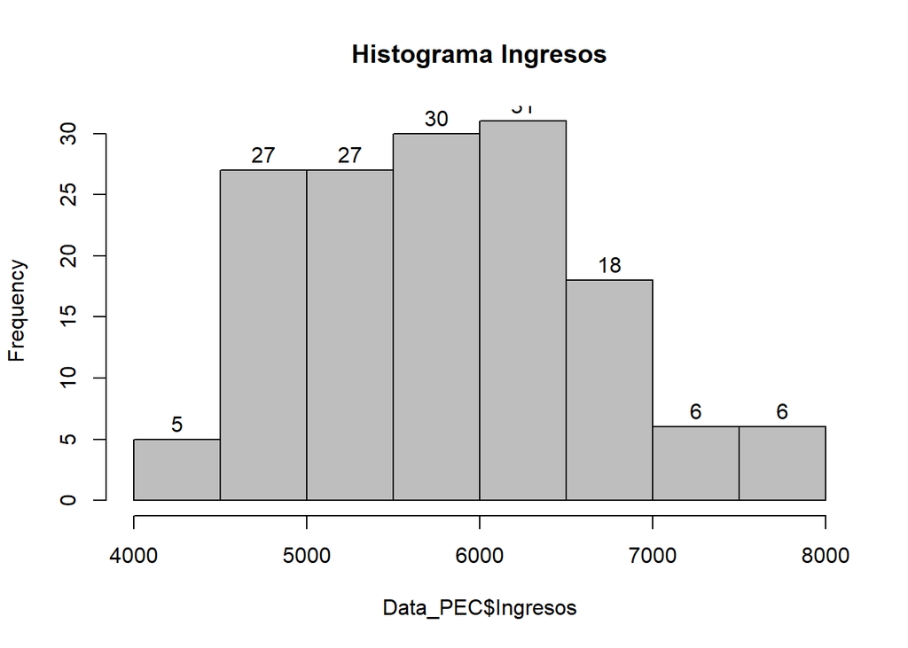

```r
# 2.Representamos gráficamente las variables del fichero mediante histogramas

#Histograma Ingresos
f1 <- hist(Data_PEC$Ingresos, main="Histograma Ingresos", col = "gray", labels = TRUE)
```

```r
f1
```

```
## $breaks
## [1] 4000 4500 5000 5500 6000 6500 7000 7500 8000
##
## $counts
## [1]  5 27 27 30 31 18  6  6
##
## $density
## [1] 6.666667e-05 3.600000e-04 3.600000e-04 4.000000e-04 4.133333e-04
## [6] 2.400000e-04 8.000000e-05 8.000000e-05
##
## $mids
## [1] 4250 4750 5250 5750 6250 6750 7250 7750
##
## $xname
## [1] "Data_PEC$Ingresos"
##
## $equidist
## [1] TRUE
##
## attr(,"class")
## [1] "histogram"
```

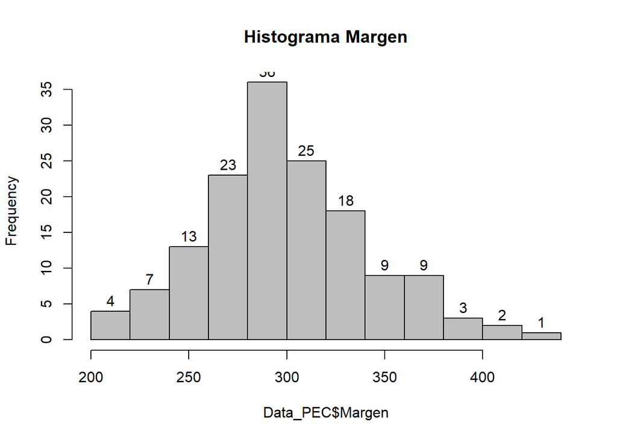

```r
#Histograma Margen
f2 <- hist(Data_PEC$Margen, main="Histograma Margen", col = "gray", labels = TRUE)
```

```r
f2
```

```
## $breaks
##  [1] 200 220 240 260 280 300 320 340 360 380 400 420 440
##
## $counts
##  [1]  4  7 13 23 36 25 18  9  9  3  2  1
##
## $density
##  [1] 0.0013333333 0.0023333333 0.0043333333 0.0076666667 0.0120000000
##  [6] 0.0083333333 0.0060000000 0.0030000000 0.0030000000 0.0010000000
## [11] 0.0006666667 0.0003333333
##
## $mids
##  [1] 210 230 250 270 290 310 330 350 370 390 410 430
##
## $xname
## [1] "Data_PEC$Margen"
##
## $equidist
## [1] TRUE
##
## attr(,"class")
## [1] "histogram"
```

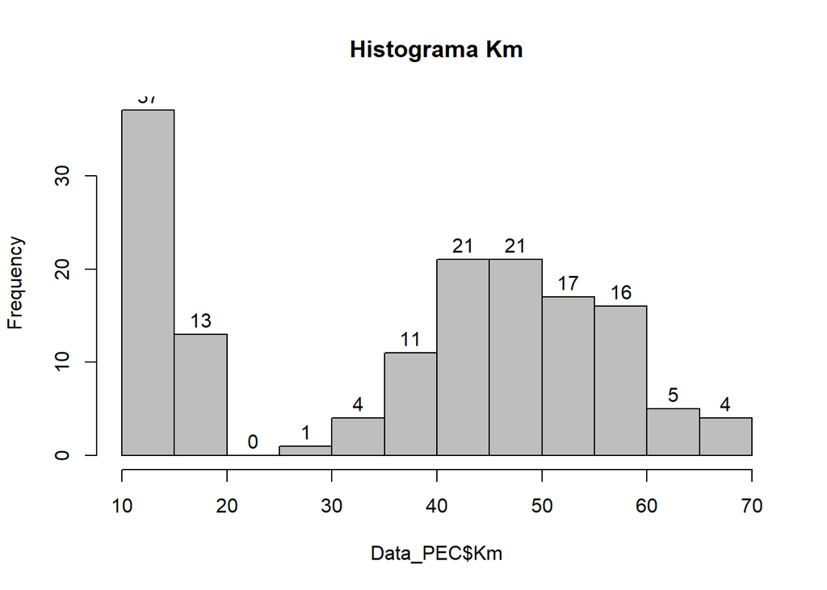

```r
#Histograma Km
f3 <- hist(Data_PEC$Km, main="Histograma Km", col = "gray", labels = TRUE)
```

```r
f3
```

```
## $breaks
##  [1] 10 15 20 25 30 35 40 45 50 55 60 65 70
##
## $counts
##  [1] 37 13  0  1  4 11 21 21 17 16  5  4
##
## $density
##  [1] 0.049333333 0.017333333 0.000000000 0.001333333 0.005333333 0.014666667
##  [7] 0.028000000 0.028000000 0.022666667 0.021333333 0.006666667 0.005333333
##
## $mids
##  [1] 12.5 17.5 22.5 27.5 32.5 37.5 42.5 47.5 52.5 57.5 62.5 67.5
##
## $xname
## [1] "Data_PEC$Km"
##
## $equidist
## [1] TRUE
##
## attr(,"class")
## [1] "histogram"
```

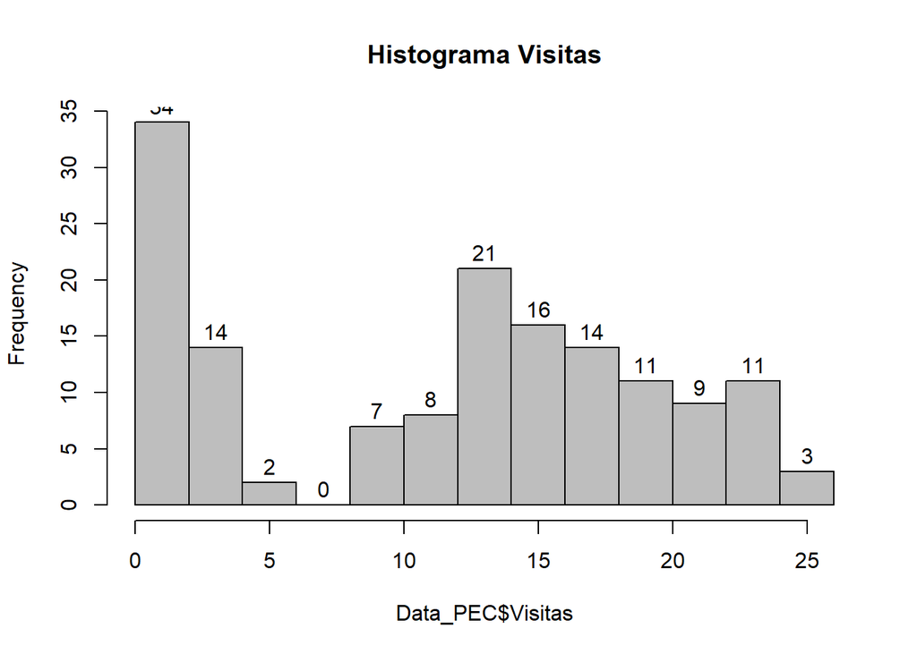

```r
#Histograma Visitas
f4 <- hist(Data_PEC$Visitas, main="Histograma Visitas", col = "gray", labels = TRUE)
```

```r
f4
```

```
## $breaks
##  [1]  0  2  4  6  8 10 12 14 16 18 20 22 24 26
##
## $counts
##  [1] 34 14  2  0  7  8 21 16 14 11  9 11  3
##
## $density
##  [1] 0.113333333 0.046666667 0.006666667 0.000000000 0.023333333 0.026666667
##  [7] 0.070000000 0.053333333 0.046666667 0.036666667 0.030000000 0.036666667
## [13] 0.010000000
##
## $mids
##  [1]  1  3  5  7  9 11 13 15 17 19 21 23 25
##
## $xname
## [1] "Data_PEC$Visitas"
##
## $equidist
## [1] TRUE
##
## attr(,"class")
## [1] "histogram"
```

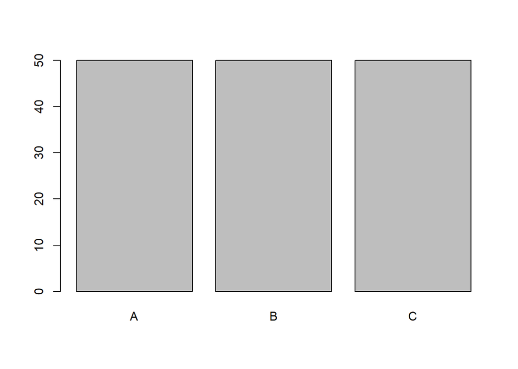

```r
#Histograma Comercial
f5 <- plot(Data_PEC$Comercial)
```

```r
f5
```

```
##      [,1]
## [1,]  0.7
## [2,]  1.9
## [3,]  3.1
```

Las variables cuantitativas presentan dos distribuciones diferenciadas:

- *Importe* y *Margen* presentan una distribución similar a una campana de *Gauss*, algo más concentrada en el caso de *Margen*
- *Km* y *Visitas* presentan una distribución muy similar. Con una alta concentración para valores bajos que desciende rápidamente para volver a crecer siguiendo una campana de *Gauss* a partir del tercer valor de la serie.

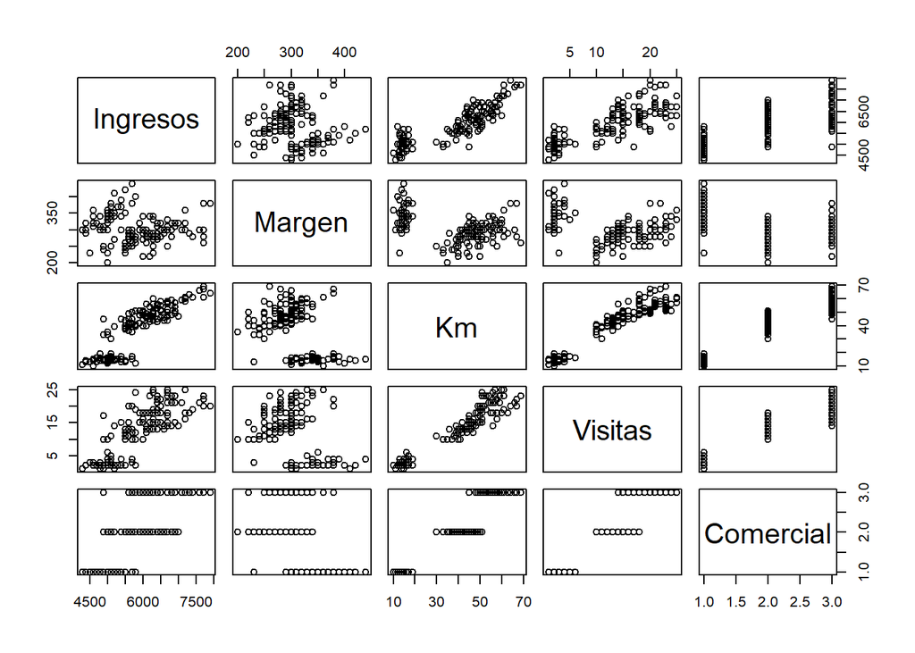

```r
# 3.Estudiamos la relación existente entre las variables del fichero

# Estudiamos la relación entre variables mediante gráficos de dispersión
f6<- plot(Data_PEC)
```

```r
# Estudiamos la relación entre variables cuantitativas mediante correlaciones
cor(Data_PEC[,c("Ingresos","Margen","Km","Visitas")], use="complete")
```

```
##            Ingresos     Margen         Km    Visitas
## Ingresos  1.0000000 -0.1093692  0.8717542  0.8179536
## Margen   -0.1093692  1.0000000 -0.4205161 -0.3565441
## Km        0.8717542 -0.4205161  1.0000000  0.9627571
## Visitas   0.8179536 -0.3565441  0.9627571  1.0000000
```

- Coeficiente de Correlación *Visitas*-*Km* -> (0,96)
- Coeficiente de Correlación *Ingresos*-*Km* -> (0,87)
- Coeficiente de Correlación *Ingresos*-*Visitas* -> (0,82)
- Coeficiente de Correlación *Margen*-*Km* -> (-0,42)

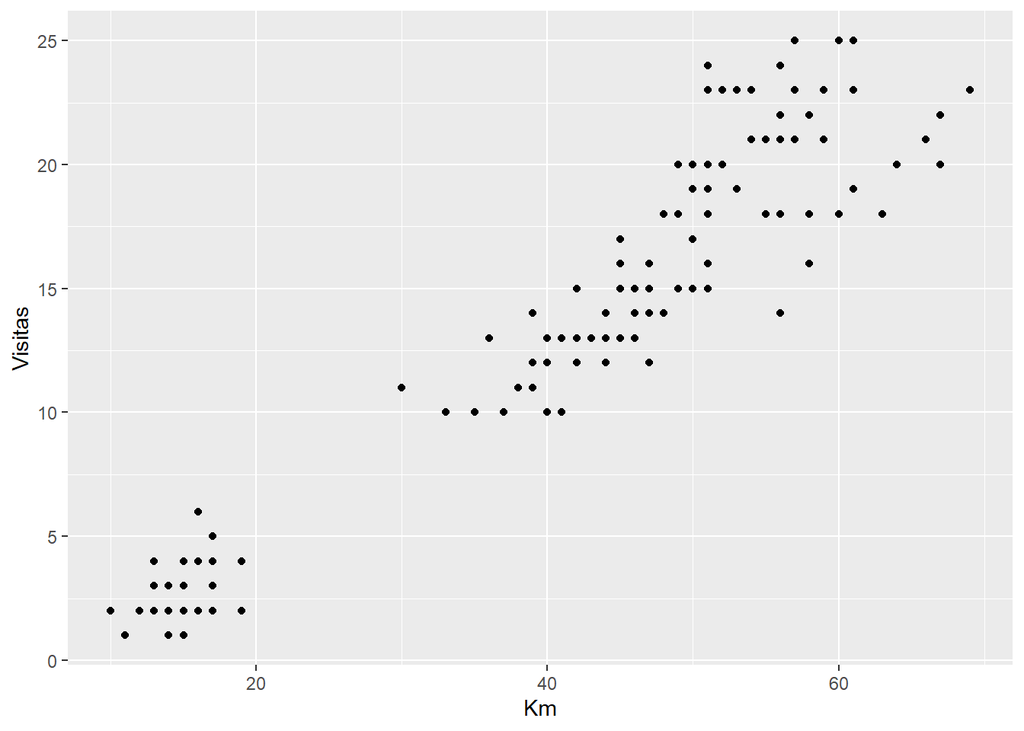

```r
# Estudiamos la relación entre variables Km y Visitas
f7<-ggplot(Data_PEC, aes(x=Km, y=Visitas)) + geom_point()
f7
```

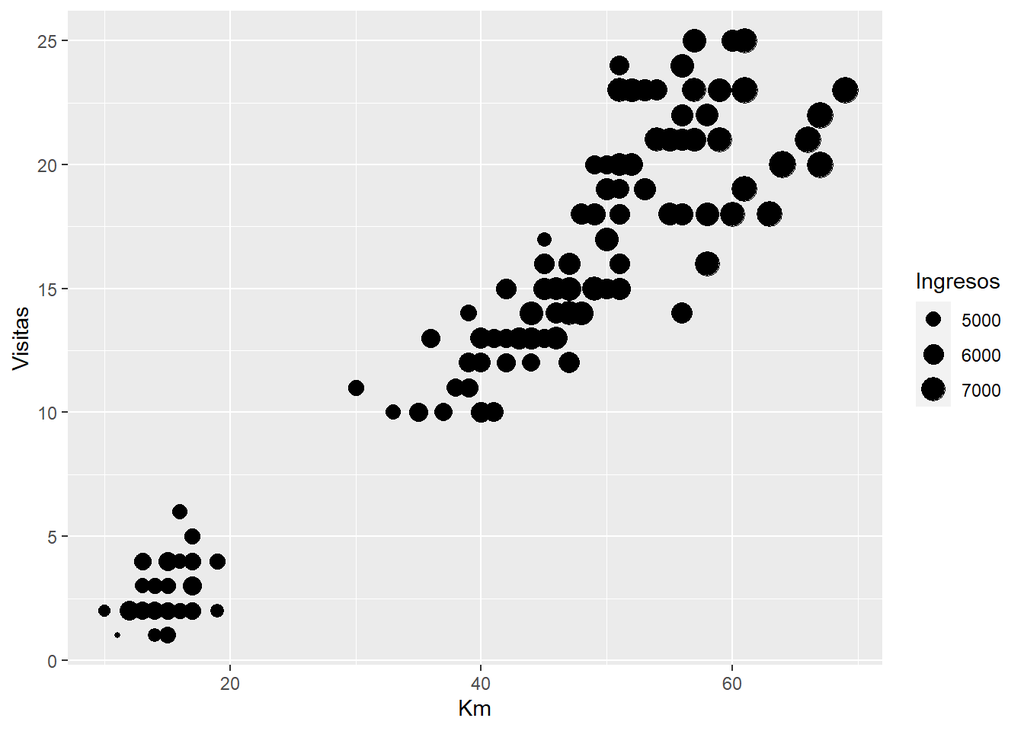

```r
# Estudiamos la relación entre variables Km y Visitas con tamañoo ingresos
f8<-ggplot(Data_PEC, aes(x=Km, y=Visitas)) + geom_point(aes(size=Ingresos))
f8
```

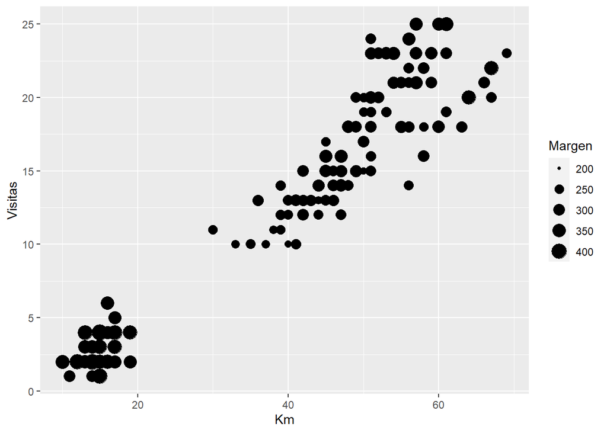

```r
# Relación entre variables Km y Visitas con tamaño margen
f9<-ggplot(Data_PEC, aes(x=Km, y=Visitas)) + geom_point(aes(size=Margen))
f9
```

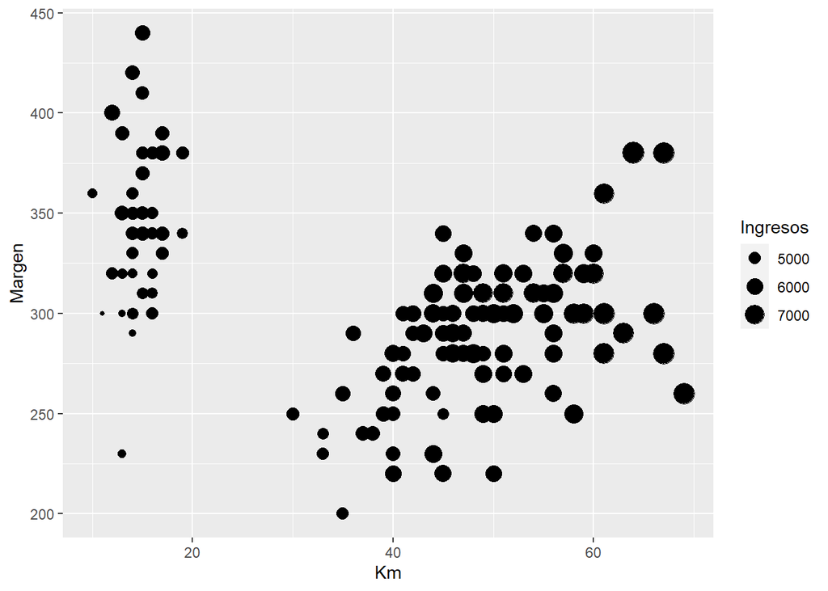

```r
# Relación entre variables Km y Visitas con tamaño margen
fA<-ggplot(Data_PEC, aes(x=Km, y=Margen)) + geom_point(aes(size=Ingresos))
fA
```

```r
# 3.Estudiamos la existencia de diferencias por Comercial

# promedio variables por comercial
tapply(Data_PEC$Ingresos,Data_PEC$Comercial,mean)
```

```
##    A    B    C
## 5006 5936 6588
```

```r
tapply(Data_PEC$Margen,Data_PEC$Comercial,mean)
```

```
##     A     B     C
## 341.8 277.0 297.4
```

```r
tapply(Data_PEC$Km,Data_PEC$Comercial,mean)
```

```
##     A     B     C
## 14.64 42.60 55.52
```

```r
tapply(Data_PEC$Visitas,Data_PEC$Comercial,mean)
```

```
##     A     B     C
##  2.44 13.26 20.26
```

Vemos que existen diferencias remarcables en el promedio de cada una de las variables para cada Comercial:

Graficamos a continuación las variables cuantitativas diferenciando por Comercial.

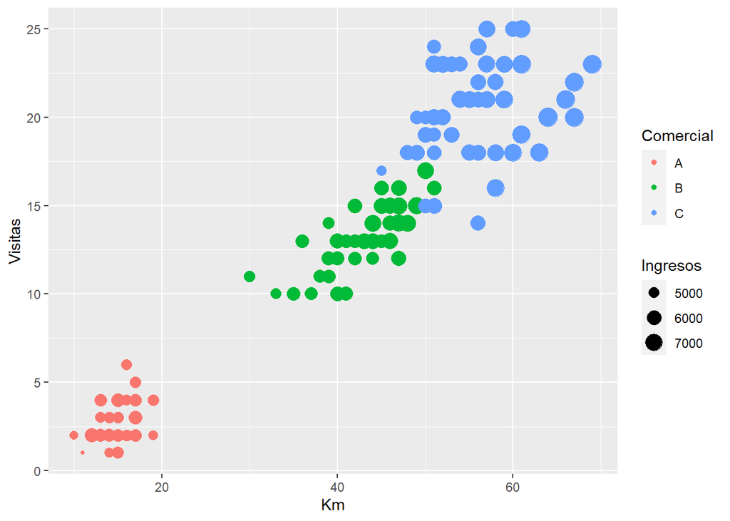

```r
# Relación entre variables Km y Visitas con tamaño ingresos y Color según Comercial
f10<-ggplot(Data_PEC, aes(x=Km, y=Visitas, color=Comercial)) + geom_point(aes(size=Ingresos))
f10
```

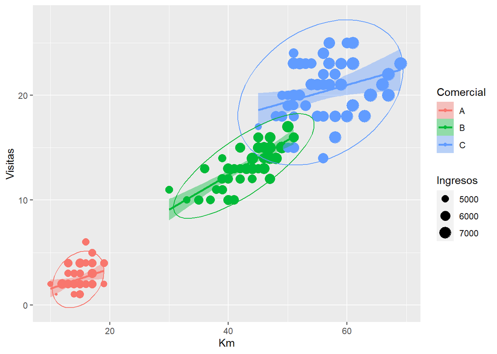

```r
# Relación entre variables Km y Visitas con tamaño ingresos y Color según Comercial, línea tendencia y elipse
f11<-ggplot(Data_PEC, aes(x=Km, y=Visitas, color=Comercial)) + geom_point(aes(size=Ingresos)) + geom_smooth(method=lm, aes(fill=Comercial))+ stat_ellipse(type = "norm")
f11
```

Identificamos un comportamiento diferenciado donde *Km* y *Visitas* ya que son las variables que presentan una mayor capacidad de diferenciación.

# 7 Preparación de los conjuntos de entrenamiento y validación

Construimos un **juego de datos de entrenamiento** con el 70% de registros para construir los modelos y un **juego de datos de pruebas o validación** con el 30% de registros restantes para validar los modelos. Esta separación de ambos conjuntos es aleatoria.

Separamos los datos en entrenamiento y validación antes de proceder con el resto de ejercicios para asegurar que los datos de entrenamiento y validación son iguales en todos los casos y los resultados son comparables. Si lo hiciésemos de otro modo, las diferencias en la calidad de los modelos podrían ser debidas a una separación distinta entre los conjuntos de entrenamiento y validación.

```r
# Dividimos el fichero en 70% entreno y 30% validación  #
RNGversion('3.5.3') # fijaremos el criterio de generación de números aleatorios para que todos obtengamos los mismos resultados
set.seed(1234)  # Seed inicializa el generador de números aleatorios que usaremos para separar los datos en train y test. Usando un seed fijo, nos aseguramos de que todos generamos los mismos conjuntos y los resultados son reproducibles
ind <- sample(2, nrow(Data_PEC), replace=TRUE, prob=c(0.7, 0.3))
trainData <- Data_PEC[ind==1,]
testData <- Data_PEC[ind==2,]
```

# 8 Proceso de clasificación mediante SVM utilizando el paquete e1071.

**Aplicamos el modelo SVM**, pasándole como parámetros la matriz de entrenamiento compuesta por las 4 variables cuantitativas : *Importe*, *Margen*, *Km* y *Visitas*. No le pasamos el campo *Comercial* porque precisamente es el campo que el algoritmo debe predecir.

```r
# Entrenamos el modelo SVM
model_svm = svm(trainData[,1:4], trainData$Comercial)
# Usamos el modelo que hemos entrenado para generar una predicción para cada muestra del conjunto de validación
preds_svm = predict(model_svm, testData[,1:4])
# Calculamos el % de aciertos de nuestro modelo
sum(preds_svm == testData$Comercial)/ length(testData$Comercial)*100
```

```
## [1] 94.73684
```

Evaluamos el % de acierto del modelo SVM que hemos entrenado.

SVM genera un 94.73% de acierto sobre los datos propuestos.

# 9 Proceso de clasificación mediante SVM utilizando el paquete caret

Comenzamos entrenando el modelo SVM lineal con el paquete caret

```r
# Modelo SVM Lineal
svm.caret <- train(Comercial~., data=trainData, method = 'svmLinear', trControl = trainControl(method = "cv"))
svm.caret
```

```
## Support Vector Machines with Linear Kernel
##
## 112 samples
##   4 predictor
##   3 classes: 'A', 'B', 'C'
##
## No pre-processing
## Resampling: Cross-Validated (10 fold)
## Summary of sample sizes: 100, 101, 100, 101, 101, 101, ...
## Resampling results:
##
##   Accuracy   Kappa
##   0.9560606  0.9335717
##
## Tuning parameter 'C' was held constant at a value of 1
```

En la salida del modelo podemos visualizar la capacidad predictiva del modelo mediante las métricas Accuracy y Kappa en el conjunto de entrenamiento. Adicionalmente vamos a calcular la matriz de confusión sobre el conjunto de test para poder profundizar más y descartar el overfitting.

```r
# Realizamos las predicciones del modelo sobre el conjunto de test
preds_svm.caret<-predict(svm.caret, testData)
# Matriz de confusión
confusionMatrix(preds_svm.caret,testData$Comercial)
```

```
## Confusion Matrix and Statistics
##
##           Reference
## Prediction  A  B  C
##          A 10  0  0
##          B  0 12  2
##          C  0  0 14
##
## Overall Statistics
##
##                Accuracy : 0.9474
##                  95% CI : (0.8225, 0.9936)
##     No Information Rate : 0.4211
##     P-Value [Acc > NIR] : 7.335e-12
##
##                   Kappa : 0.9202
##
##  Mcnemar's Test P-Value : NA
##
## Statistics by Class:
##
##                      Class: A Class: B Class: C
## Sensitivity            1.0000   1.0000   0.8750
## Specificity            1.0000   0.9231   1.0000
## Pos Pred Value         1.0000   0.8571   1.0000
## Neg Pred Value         1.0000   1.0000   0.9167
## Prevalence             0.2632   0.3158   0.4211
## Detection Rate         0.2632   0.3158   0.3684
## Detection Prevalence   0.2632   0.3684   0.3684
## Balanced Accuracy      1.0000   0.9615   0.9375
```

Vemos que el acierto es similar al del conjunto de entrenamiento descartando el overfitting y podemos apreciar tanto las métricas generales del modelo como las métricas particulares de cada una de las categorías.

# 10 Proceso de clasificación mediante Árboles de decisión simples

Para construir un árbol de decisión es necesario definir una función que relaciona una variable categórica dependiente (factor) con *n* variables independientes que pueden ser categóricas o numéricas. En nuestro caso trabajaremos con:

- 1 variable factor dependiente -> *Comercial*
- 4 variables independientes -> *Ingresos*, *Margen*, *Km* y *Visitas*

El algoritmo de clasificación busca cuál es la variable que permite obtener una submuestra más diferenciada para la variable dependiente (*Comercial* en nuestro caso) e identifica también qué intervalos (si la variable es cuantitativa) ó agrupación de categorías de la/s variable/s independiente/s permitiría/n maximizar dicha división.

Una vez identificada la variable independiente que permite obtener la clasificación con una mayor capacidad de diferenciación, el proceso se repite reiterativamente en cada uno de los nodos obtenidos hasta que el algoritmo no encuentra diferencias significativas que le permitan seguir profundizando en los nodos.

Una vez obtenido una primera versión del árbol, existen algoritmos que permiten hacer un podado del árbol (*prunning*), eliminando aquellas ramas que no acaban de justificar su presencia de acuerdo con algunos parámetros preestablecidos.

En todos los casos seguiremos la siguiente secuencia de pasos para obtener los Árboles de clasificación:

1. Definir la función que relaciona la variable dependiente con las variables independientes
2. Estimar el árbol de decisión
3. Representar gráficamente una primera versión del árbol
- Estudiar la aplicación práctica del resultado obtenido
- Podar el árbol (si el algoritmo admite podado)
4. Estudiar la capacidad predictiva del árbol

Estudiamos a continuación la capacidad predictiva del Árbol de decisión simple obtenido mediante el paquete *rpart*

```r
# Declaramos función del árbol
ArbolRpart = Comercial ~ Ingresos + Margen + Km + Visitas
# Aplicamos algoritmo
model_tree = rpart(ArbolRpart, method="class", data=trainData)
# Validamos la capacidad de predicción del árbol con el fichero de validación
preds_tree <- predict(model_tree, newdata = testData, type = "class")
# Visualizamos una matriz de confusión
table(preds_tree, testData$Comercial)
```

```
##
## preds_tree  A  B  C
##          A 10  0  0
##          B  0 12  2
##          C  0  0 14
```

```r
# Calculamos el % de aciertos
sum(preds_tree == testData$Comercial)/ length(testData$Comercial)*100
```

```
## [1] 94.73684
```

El árbol de decisión obtenido mediante el paquete *rpart* clasifica correctamente un 94,73% de los registros. Un resultado bastante alto y aceptable.

Una vez construida una primera versión del árbol, estudiamos la viabilidad de un podado de árbol.

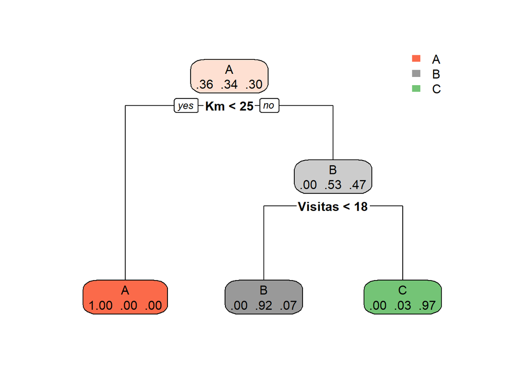

```r
# Podado del árbol
pruned_tree_model <- prune(model_tree, cp= model_tree$cptable[which.min(model_tree$cptable[,"xerror"]),"CP"])
pruned_tree_model <- prune(pruned_tree_model, cp= 0.02)
# Representación del árbol podado
f14<-rpart.plot(pruned_tree_model,extra=4) #visualizamos el árbol
```

```r
f14
```

[output not shown]

[output cut: 23 more lines]

[output not shown]

Dado que el árbol original es muy simple. El podado no devuelve ninguna versión nueva reducida.

# 11 Proceso de clasificación mediante Árboles de decisión simples utilizando el paquete caret

Comenzamos entrenando un modelo basado en arboles de decisión con el paquete caret utilizando una validación cruzada. Si leeis la documentación comprobaréis que se basan en la misma librería puesto que caret es un agregados y homogeneizador de múltiples algoritmos.

```r
# Modelo SVM Lineal
tree.caret <- train(Comercial~., data=trainData,method = 'rpart', trControl = trainControl(method = "cv"))
tree.caret
```

```
## CART
##
## 112 samples
##   4 predictor
##   3 classes: 'A', 'B', 'C'
##
## No pre-processing
## Resampling: Cross-Validated (10 fold)
## Summary of sample sizes: 101, 101, 100, 101, 102, 100, ...
## Resampling results across tuning parameters:
##
##   cp         Accuracy   Kappa
##   0.0000000  0.9193939  0.8786124
##   0.4166667  0.7519697  0.6237403
##   0.5277778  0.5154545  0.2521645
##
## Accuracy was used to select the optimal model using the largest value.
## The final value used for the model was cp = 0.
```

En la salida del modelo podemos visualizar la capacidad predictiva del modelo mediante las métricas Accuracy, Kappa y la complejidad paramétrica en el conjunto de entrenamiento.

Podemos representar visualmente el modelo final seleccionado

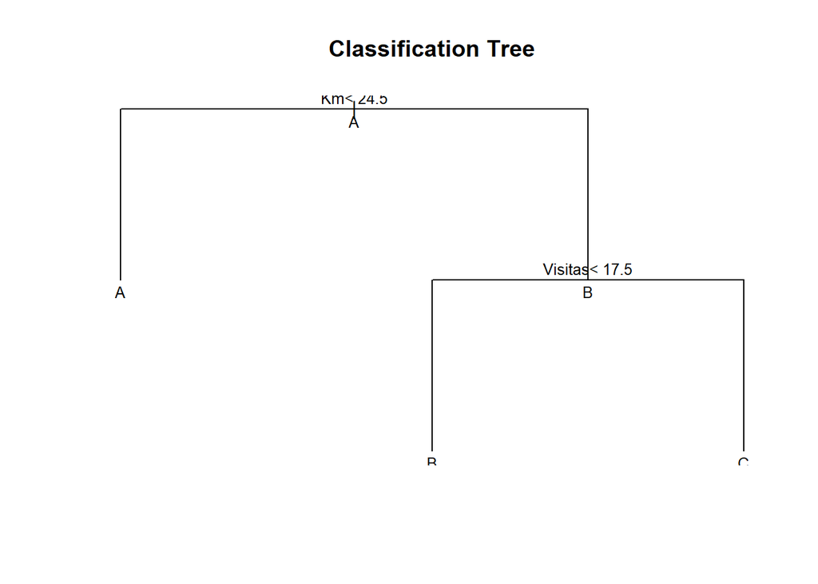

```r
plot(tree.caret$finalModel, uniform=TRUE,main="Classification Tree")
text(tree.caret$finalModel, use.na=TRUE, all=TRUE, cex=.8)
```

En este caso, vemos que la salida proporcionada por la librería rpart es más vistosa.

Adicionalmente vamos a calcular la matriz de confusión sobre el conjunto de test para poder profundizar más y descartar el overfitting.

```r
# Realizamos las predicciones del modelo sobre el conjunto de test
preds_tree.caret<-predict(tree.caret, testData)
# Matriz de confusión
confusionMatrix(preds_tree.caret,testData$Comercial)
```

```
## Confusion Matrix and Statistics
##
##           Reference
## Prediction  A  B  C
##          A 10  0  0
##          B  0 12  2
##          C  0  0 14
##
## Overall Statistics
##
##                Accuracy : 0.9474
##                  95% CI : (0.8225, 0.9936)
##     No Information Rate : 0.4211
##     P-Value [Acc > NIR] : 7.335e-12
##
##                   Kappa : 0.9202
##
##  Mcnemar's Test P-Value : NA
##
## Statistics by Class:
##
##                      Class: A Class: B Class: C
## Sensitivity            1.0000   1.0000   0.8750
## Specificity            1.0000   0.9231   1.0000
## Pos Pred Value         1.0000   0.8571   1.0000
## Neg Pred Value         1.0000   1.0000   0.9167
## Prevalence             0.2632   0.3158   0.4211
## Detection Rate         0.2632   0.3158   0.3684
## Detection Prevalence   0.2632   0.3684   0.3684
## Balanced Accuracy      1.0000   0.9615   0.9375
```

Vemos que el acierto es similar al del conjunto de entrenamiento descartando el overfitting y podemos apreciar tanto las métricas generales del modelo como las métricas particulares de cada una de las categorías.

# 12 Proceso de clasificación mediante árboles de decisión múltiples (paquete randomForest)

El algoritmo *randomForest* es un método de estimación combinado, donde el resultado de la estimación se construye a partir de los resultados obtenidos mediante el cálculo de *n* árboles donde los predictores son incluidos al azar.

Es un método complejo con ventajas e inconvenientes respecto a los árboles de clasificación simples:

*Ventajas*

- Es uno de los algoritmos de aprendizaje más precisos
- Se ejecuta eficientemente en grandes bases de datos
- Permite trabajar con cientos de variables independientes sin excluir ninguna
- Determina la importancia en la clasificación de cada variable
- Recupera eficazmente los valores perdidos de un dataset (*missings*)
- Permite evaluar la ganancia en clasificación obtenida a medida que incrementamos el número de árboles generados en el modelo.

*Inconvenientes*

- A diferencia de los árboles de decisión, la clasificación hecha por *random forests* es difícil de interpretar
- Favorece las variables categóricas que tienen un mayor número de niveles por encima de aquéllas que tienen un número de categoría más reducido. Comprometiendo la fiabilidad del modelo para este tipo de datos.
- Favorece los grupos más pequeños cuando las variables están correlacionadas
- randomForest sobreajusta en ciertos grupos de datos con tareas de clasificación/regresión ruidosas

```r
set.seed(123)
#Declaramos función del árbol
ArbolRF <- Comercial ~ Ingresos + Margen + Km + Visitas
#Aplicamos algoritmo
model_random_forest <- randomForest(ArbolRF, data=trainData, ntree=500,proximity=T,nodesize=5) #indicamos el número de árboles mediante ntree=500
#Obtenemos la importancia de cada variable en el proceso de clasificación
importance(model_random_forest)      #Importancia de las variables en formato text
```

```
##          MeanDecreaseGini
## Ingresos        6.7638264
## Margen          0.9610651
## Km             30.6510276
## Visitas        32.9783037
```

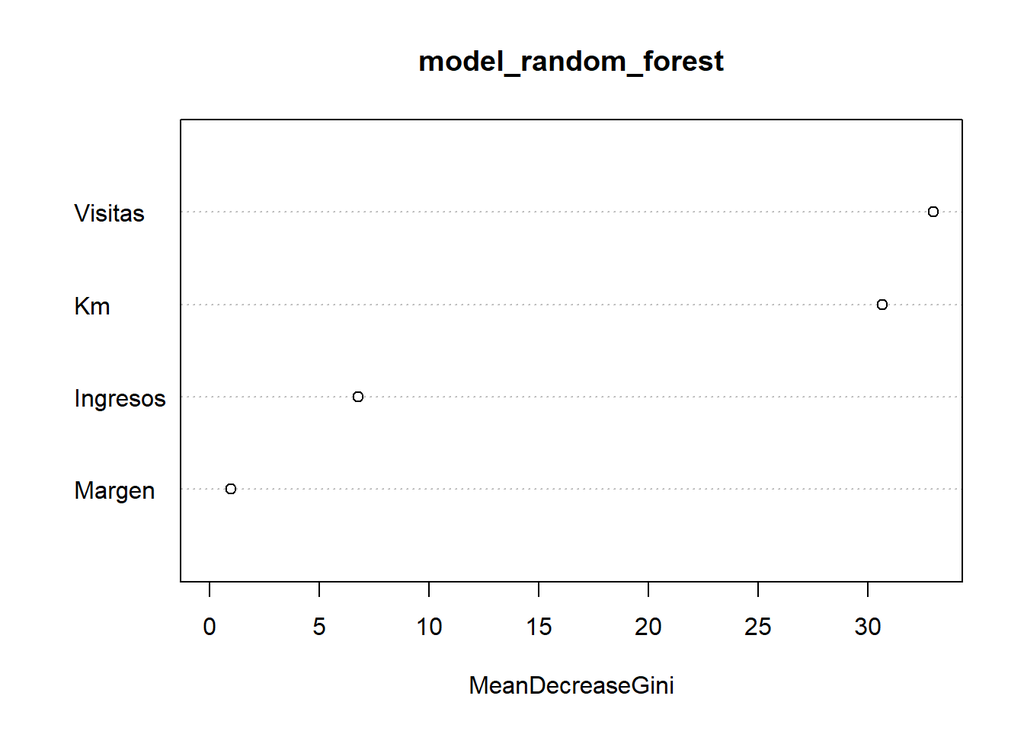

```r
f15<-varImpPlot(model_random_forest) #Importancia de las variables en formato gráfico
```

```r
f15
```

```
##          MeanDecreaseGini
## Ingresos        6.7638264
## Margen          0.9610651
## Km             30.6510276
## Visitas        32.9783037
```

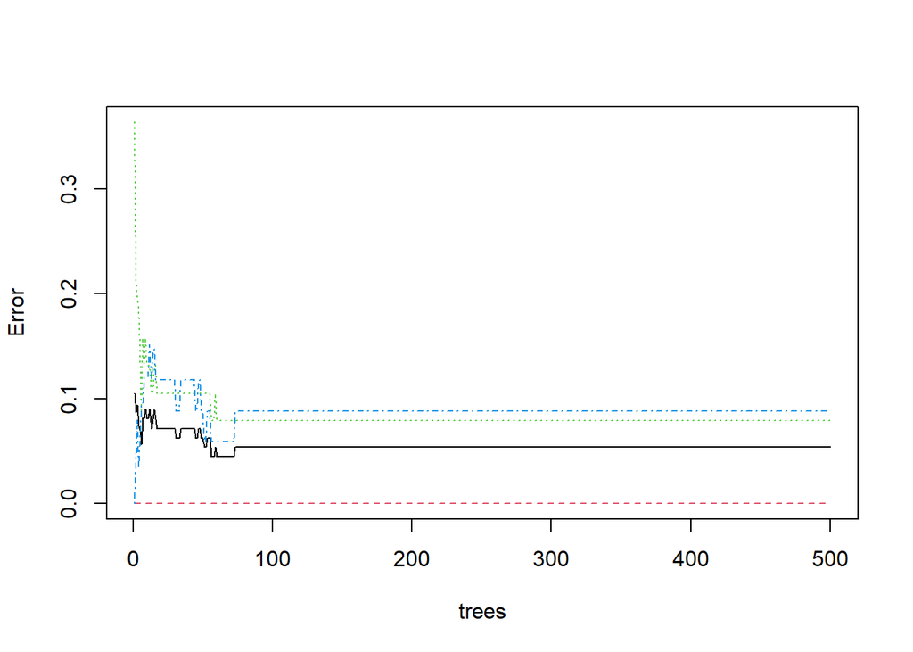

```r
#evolución del error según el número de árboles
f16<-plot(model_random_forest, main = "")
```

```r
head(f16)
```

```
##             OOB A          B          C
## [1,] 0.10526316 0 0.36363636 0.00000000
## [2,] 0.08695652 0 0.21739130 0.04347826
## [3,] 0.09411765 0 0.19354839 0.08000000
## [4,] 0.07368421 0 0.18750000 0.03333333
## [5,] 0.07000000 0 0.14705882 0.06451613
## [6,] 0.05660377 0 0.08333333 0.09375000
```

```r
# Validamos la capacidad de predicción del árbol con el fichero de validación
preds_random_forest <- predict(model_random_forest, newdata = testData)
table(preds_random_forest, testData$Comercial)
```

```
##
## preds_random_forest  A  B  C
##                   A 10  0  0
##                   B  0 12  1
##                   C  0  0 15
```

```r
# Calculamos el % de aciertos
sum(preds_random_forest == testData$Comercial)/ length(testData$Comercial)*100
```

```
## [1] 97.36842
```

El árbol de decisión obtenido mediante el paquete *randomForest* clasifica correctamente un 97,36% de los registros. Un resultado bastante alto y aceptable.

# 13 Ejercicios

## 13.1 Pregunta 1

En el gráfico f10 mostramos la relación entre las variables Visitas, KM e Ingresos diferenciando por colores entre las categorías. Realice 2 gráficos similares que muestren las variables Km y Margen utilizando el dataset de validación testData. En el primer gráfico se tienen que colorear los elementos con su categoría real, en el segundo se tienen que colorear con la prediccion realizada utilizando el modelo model_svm entrenado anteriormente. En ambos gráficos se tiene que mostrar si las predicciones son correctas o no utilizando formas distintas para los aciertos y para los fallos.

## 13.2 Respuesta 1

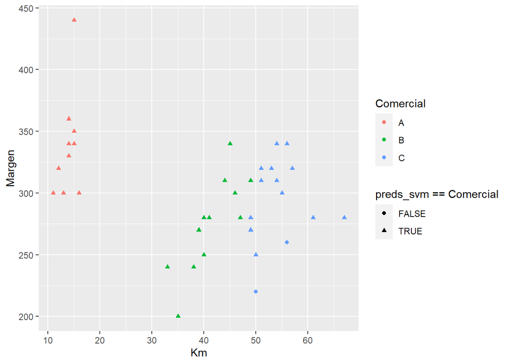

```r
#Elementos con categoría real:
f22<-ggplot(testData, aes(x=Km, y=Margen, color=Comercial))+geom_point(aes(shape=preds_svm==Comercial))
f22
```

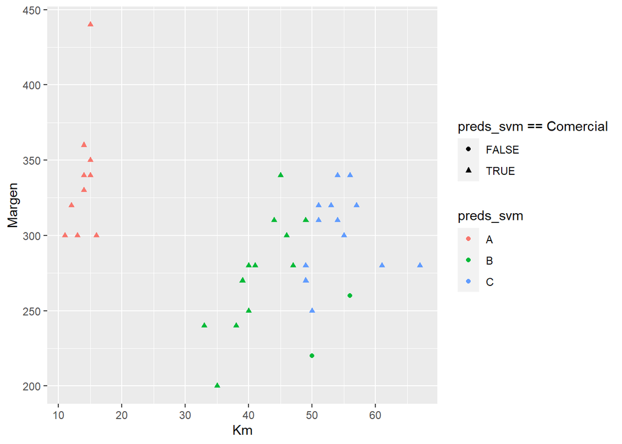

```r
#Predicción:
f23<-ggplot(testData, aes(x=Km, y=Margen, color=preds_svm))+geom_point(aes(shape=preds_svm==Comercial))
f23
```

## 13.3 Pregunta 2

Entrene un modelo de RandomForest mediante el paquete Caret que no sea el modelo rf (enlace: http://topepo.github.io/caret/train-models-by-tag.html y buscar la familia Random Forest) y muestre su matrix de confusión sobre el conjunto de test. Analice los valores de la métrica Sensitivity de cada una de las clases. ¿Qué es esa métrica? ¿Qué conclusiones obtiene de los resultados con respecto a esa métrica?

## 13.4 Respuesta 2

> Usamos el modelo Parallel Random Forest.

```r
#Cargamos librería:
library('e1071')

#Aplicamos train con el metodo parRF:
prueba.parRF <- train(Comercial~., data=trainData,method = 'parRF', trControl = trainControl(method = "cv"))
prueba.parRF
```

```
## Parallel Random Forest
##
## 112 samples
##   4 predictor
##   3 classes: 'A', 'B', 'C'
##
## No pre-processing
## Resampling: Cross-Validated (10 fold)
## Summary of sample sizes: 101, 101, 101, 101, 101, 100, ...
## Resampling results across tuning parameters:
##
##   mtry  Accuracy   Kappa
##   2     0.9553030  0.9324957
##   3     0.9462121  0.9185717
##   4     0.9462121  0.9185717
##
## Accuracy was used to select the optimal model using the largest value.
## The final value used for the model was mtry = 2.
```

```r
# Realizamos las predicciones del modelo sobre el conjunto de test:
preds_prueba.parRF<-predict(prueba.parRF, testData)
# Matriz de confusión:
confusionMatrix(preds_prueba.parRF,testData$Comercial)
```

```
## Confusion Matrix and Statistics
##
##           Reference
## Prediction  A  B  C
##          A 10  0  0
##          B  0 12  2
##          C  0  0 14
##
## Overall Statistics
##
##                Accuracy : 0.9474
##                  95% CI : (0.8225, 0.9936)
##     No Information Rate : 0.4211
##     P-Value [Acc > NIR] : 7.335e-12
##
##                   Kappa : 0.9202
##
##  Mcnemar's Test P-Value : NA
##
## Statistics by Class:
##
##                      Class: A Class: B Class: C
## Sensitivity            1.0000   1.0000   0.8750
## Specificity            1.0000   0.9231   1.0000
## Pos Pred Value         1.0000   0.8571   1.0000
## Neg Pred Value         1.0000   1.0000   0.9167
## Prevalence             0.2632   0.3158   0.4211
## Detection Rate         0.2632   0.3158   0.3684
## Detection Prevalence   0.2632   0.3684   0.3684
## Balanced Accuracy      1.0000   0.9615   0.9375
```

> En el caso de este modelo entrenado, la clase “A” y “B” que nos dan 1, nos indican que el 100% de las categorías fueron correctamente predichas Sin embargo para la clase “C”, con 0.8750, nos indica que un 87,5% de esta clase fue correctamente predecida como clase “C”.

## 13.5 Pregunta 3

Calcula una predicción de clasificación utilizando el algoritmo KNN con k=2. Compare los resultados con los obtenidos utilizando el modelo model_svm

## 13.6 Respuesta 3

```r
#Cargamos la librería:
library(caret)

#Establecemos la malla:
knnGrid <-  expand.grid(k = c(1:2))
#Entrenamos el Modelo knn:
knn.caret <- train(Comercial~., data=trainData ,method = "knn",tuneGrid = knnGrid)


#Realizamos la predicción del modelo entrenado:
pred_knn<-predict(knn.caret, testData)
confusionMatrix(pred_knn,testData$Comercial)
```

```
## Confusion Matrix and Statistics
##
##           Reference
## Prediction  A  B  C
##          A 10  0  0
##          B  0  9  6
##          C  0  3 10
##
## Overall Statistics
##
##                Accuracy : 0.7632
##                  95% CI : (0.5976, 0.8856)
##     No Information Rate : 0.4211
##     P-Value [Acc > NIR] : 1.925e-05
##
##                   Kappa : 0.6423
##
##  Mcnemar's Test P-Value : NA
##
## Statistics by Class:
##
##                      Class: A Class: B Class: C
## Sensitivity            1.0000   0.7500   0.6250
## Specificity            1.0000   0.7692   0.8636
## Pos Pred Value         1.0000   0.6000   0.7692
## Neg Pred Value         1.0000   0.8696   0.7600
## Prevalence             0.2632   0.3158   0.4211
## Detection Rate         0.2632   0.2368   0.2632
## Detection Prevalence   0.2632   0.3947   0.3421
## Balanced Accuracy      1.0000   0.7596   0.7443
```

> Para knn el % de precisión es solo del 76% comparado con el 94% que tuvimos para svm. Se han clasificado bien todas las clases “A”, pero ha habido bastantes errores en “B” y “C”.

> Vemos en efecto que Sensitivity es del 100% para “A”, pero del 75% para “B” y del 62,5% para “C”. El valor Kappa para knn es del 0,6423. Para ser un modelo informativo debería estar más cercano a 1. En svm el valor es 0,92, por lo que es un modelo mucho más informativo.

> El p-valor también es más bajo en smv, lo que también demuestra que es un modelo más informativo.

## 13.7 Pregunta 4

En el apartado **Proceso de Clasificación mediante árboles de decisión simple** se ha construido un árbol de decisión simple utilizando todas las variables.

Construya un árbol de decisión simple considerando sólo las variables Ingresos y Margen.

Sin podarlo, evalúe el modelo y represente gráficamente el árbol. Describa las reglas de decisión finales para las hojas.

Suponiendo que no tenemos más variables y por lo tanto no se han podido entrenar los modelos previso, ¿qué opinión tiene del árbol? ¿resultaría de alguna utilidad?

## 13.8 Respuesta 4

```r
#Carga de librerías:

library("rpart")
library("rpart.plot")

# Declaramos la función del árbol:
ArbolIngMarg = Ingresos ~ Margen
# Aplicamos el algoritmo:
model_arb = rpart(ArbolIngMarg, method="class", data=trainData)

# Validamos la capacidad de predicción del árbol con el fichero de validación:
pred_arb <- predict(model_arb, newdata = testData, type = "class")

# Visualizamos una matriz de confusión:
table(pred_arb, testData$Ingresos)
```

```
##
## pred_arb 4300 4400 4900 5000 5100 5200 5500 5600 5700 6000 6100 6200 6300 6400
##     4400    0    0    0    0    0    0    0    0    0    0    0    0    0    0
##     4500    0    0    0    0    0    0    0    0    0    0    0    0    0    0
##     4600    0    0    0    0    0    0    0    0    0    0    0    0    0    0
##     4700    0    0    0    0    0    0    0    0    0    0    0    0    0    0
##     4800    0    0    0    0    1    1    0    0    0    1    0    1    1    0
##     4900    0    0    0    0    0    0    0    0    0    0    0    0    0    0
##     5000    0    0    0    0    0    0    0    0    0    0    0    0    0    0
##     5100    0    0    0    1    0    1    0    0    1    0    0    0    0    0
##     5200    0    0    0    0    0    0    0    0    0    0    0    0    0    0
##     5300    0    0    0    0    0    0    0    0    0    0    0    0    0    0
##     5400    0    0    0    0    0    0    0    0    0    0    0    0    0    0
##     5500    0    0    1    1    0    0    1    0    0    1    0    0    0    0
##     5600    0    0    0    0    0    0    0    0    0    0    0    0    0    0
```

[output cut: 53 more lines]

```r
# Calculamos el % de aciertos:
sum(pred_arb == testData$Ingresos)/ length(testData$Ingresos)*100
```

```
## [1] 5.263158
```

> Obtenemos un % de aciertos muy bajo, tan solo del 5,26%

[figure not shown]

```r
#visualizamos el árbol
f24<-rpart.plot(model_arb,extra=2)
```

```r
f24
```

[output not shown]

[output cut: 50 more lines]

[output not shown]

> Si revisamos el gráfico de árbol podemos ver de manera más global que root para ingreso 5100 se divide entre “Yes” a >=335 y “No”. En “Yes” tenemos ingresos de 5100 con márgen de menos de 345, que finalmente nos divide en “Yes” para ingresos 4800 y “No” con ingresos 5100. En el “No” que sale del root tenemos ingreso 6700 para el que se hace un primer split de margen >=295. Para “Yes” en esta opcion tenemos ingresos de 6700. Para “No”, tenemos otro split de Ingresos 5800 con margen <245. Para “Yes” en este split tenemos un ingreso de 5500, para “No” tenemos otro split con ingresos de 5800. En este split si el margen es <275 los ingresos son 5800 y si “No” lo son, los ingresos son 6400.

> Este árbol da un porcentaje de aciertos del 5.263158 %, lo cual es muy bajo y poco útil. Los árboles de decision se componen de reglas sí-no, lo que crea limites de decisión que no son muy fluidos.

> Este árbol tampoco es muy profundo, por lo que tal vez realizar una poda no serviría de mucho en la mejora de su porcentaje de aciertos.

## 13.9 Pregunta 5

Analiza los modelos de la familia de SVM que pueden ser entrenados a través de la librería caret(enlace: http://topepo.github.io/caret/train-models-by-tag.html y buscar la familia SVM).

Elige una variante y realiza las siguientes acciones 1) Describe las diferencias con la versión lineal de SVM (svmLinear) 2) Entrena un modelo con dicha variante elegida 3) MUestra la matriz de confusión del nuevo modelo 4) Compara las predicciones obtenidas por este modelo con la versión lineal de SVM entrenada en el apartado **Proceso de clasificación mediante SVM utilizando el paquete caret**.

## 13.10 Respuesta 5

> Estudiaremos la SVMRadial.

> A nivel general las SVM buscan maximizar el margen entre los puntos pertenecientes a distintos grupos a clasificar. Su objetivo es encontrar el hiperplano óptimo que maximiza el márgen entre clases del juego de datos de entrenamiento. Las SVM se apoyan en las funciones kernel para doblar el espacio de entrada y poder realizar cortes complejos de un hiperplano.

> Teniendo en cuenta esto, el SvmLineal trata el producto escalar de dos vectores, sin transformación del espacio de características. La función kernel, en este caso, respondería enteramente a lo que entendemos por producto escalar.

> SVMRadial es de una función kernel no lineal. Se la conoce también como kernel de Gauss, generaliza el concepto de distancia entre vectores en lugar de su producto escalar. Está enfocada para modelar relaciones complejas y no lineales. Es una función muy dependiente del parámetro “y”, por lo que deberemos tenerlo en cuenta para un posible sobreentrenamiento del juego de datos.

```r
# Volvemos a revisar el modelo SVMLineal
svm.caret <- train(Comercial~., data=trainData, method = 'svmLinear', trControl = trainControl(method = "cv"))
svm.caret
```

```
## Support Vector Machines with Linear Kernel
##
## 112 samples
##   4 predictor
##   3 classes: 'A', 'B', 'C'
##
## No pre-processing
## Resampling: Cross-Validated (10 fold)
## Summary of sample sizes: 100, 101, 102, 102, 101, 100, ...
## Resampling results:
##
##   Accuracy   Kappa
##   0.9659091  0.9489198
##
## Tuning parameter 'C' was held constant at a value of 1
```

```r
# Realizamos las predicciones del modelo sobre el conjunto de test SVMLineal
preds_svm.caret<-predict(svm.caret, testData)
# Matriz de confusión
confusionMatrix(preds_svm.caret,testData$Comercial)
```

```
## Confusion Matrix and Statistics
##
##           Reference
## Prediction  A  B  C
##          A 10  0  0
##          B  0 12  2
##          C  0  0 14
##
## Overall Statistics
##
##                Accuracy : 0.9474
##                  95% CI : (0.8225, 0.9936)
##     No Information Rate : 0.4211
##     P-Value [Acc > NIR] : 7.335e-12
##
##                   Kappa : 0.9202
##
##  Mcnemar's Test P-Value : NA
##
## Statistics by Class:
##
##                      Class: A Class: B Class: C
## Sensitivity            1.0000   1.0000   0.8750
## Specificity            1.0000   0.9231   1.0000
## Pos Pred Value         1.0000   0.8571   1.0000
## Neg Pred Value         1.0000   1.0000   0.9167
## Prevalence             0.2632   0.3158   0.4211
## Detection Rate         0.2632   0.3158   0.3684
## Detection Prevalence   0.2632   0.3684   0.3684
## Balanced Accuracy      1.0000   0.9615   0.9375
```

```r
# Entrenamos el modelo SVM Radial
svm.radial <- train(Comercial~., data=trainData, method = 'svmRadial', trControl = trainControl(method = "cv"))
svm.radial
```

```
## Support Vector Machines with Radial Basis Function Kernel
##
## 112 samples
##   4 predictor
##   3 classes: 'A', 'B', 'C'
##
## No pre-processing
## Resampling: Cross-Validated (10 fold)
## Summary of sample sizes: 101, 100, 102, 101, 101, 100, ...
## Resampling results across tuning parameters:
##
##   C     Accuracy   Kappa
##   0.25  0.9393939  0.9078708
##   0.50  0.9492424  0.9235759
##   1.00  0.9500000  0.9250000
##
## Tuning parameter 'sigma' was held constant at a value of 0.5329591
## Accuracy was used to select the optimal model using the largest value.
## The final values used for the model were sigma = 0.5329591 and C = 1.
```

```r
#Predicciones sobre SVM Radial
preds_svm.radial<-predict(svm.radial, testData)
# Matriz de confusión
confusionMatrix(preds_svm.radial,testData$Comercial)
```

```
## Confusion Matrix and Statistics
##
##           Reference
## Prediction  A  B  C
##          A 10  0  0
##          B  0 12  2
##          C  0  0 14
##
## Overall Statistics
##
##                Accuracy : 0.9474
##                  95% CI : (0.8225, 0.9936)
##     No Information Rate : 0.4211
##     P-Value [Acc > NIR] : 7.335e-12
##
##                   Kappa : 0.9202
##
##  Mcnemar's Test P-Value : NA
##
## Statistics by Class:
##
##                      Class: A Class: B Class: C
## Sensitivity            1.0000   1.0000   0.8750
## Specificity            1.0000   0.9231   1.0000
## Pos Pred Value         1.0000   0.8571   1.0000
## Neg Pred Value         1.0000   1.0000   0.9167
## Prevalence             0.2632   0.3158   0.4211
## Detection Rate         0.2632   0.3158   0.3684
## Detection Prevalence   0.2632   0.3684   0.3684
## Balanced Accuracy      1.0000   0.9615   0.9375
```

> Como vemos, obtenemos los mismos resutados con los dos modelos. El método CV aplicado en los modelos nos permite encontrar los parámetros óptimos, por lo que tal vez es el mejor resultado posible en los dos casos.